# Homework 4: Temperature Prediction Model for Saint Louis

Joe M

2024-11-22

# Task 1: Model Development Using Training Data

```r
load("~/Downloads/data_training.RData")
load("~/Downloads/data_prediction.RData")
```

```r
summary(data_training)
```

```
##         Length  Class  Mode
## lon         182 -none- numeric
## lat         101 -none- numeric
## ALBEDO  1654380 -none- numeric
## CLDHGH  1654380 -none- numeric
## CLDMID  1654380 -none- numeric
## CLDLOW  1654380 -none- numeric
## QLML    1654380 -none- numeric
## SWGDN   1654380 -none- numeric
## speed   1654380 -none- numeric
## precsno 1654380 -none- numeric
## prectot 1654380 -none- numeric
## TLML    1654380 -none- numeric
```

Let’s find the coordinates of the city closest to St. Louis (from the code provided in the Assignment)

```r
stl_lat = 38.63
stl_lon = -90.20
lat_index = which.min(abs(data_training$lat - stl_lat))
lon_index = which.min(abs(data_training$lon - stl_lon))
print("Indices for lat/lon:")
```

```
## [1] "Indices for lat/lon:"
```

```r
print(lat_index)
```

```
## [1] 78
```

```r
print(lon_index)
```

```
## [1] 113
```

```r
print("Lat and lon of closest area:")
```

```
## [1] "Lat and lon of closest area:"
```

```r
print(data_training$lat[lat_index])
```

```
## [1] 38.5
```

```r
print(data_training$lon[lon_index])
```

```
## [1] -90
```

```r
print("Total lat/lon values in the dataset:")
```

```
## [1] "Total lat/lon values in the dataset:"
```

```r
print(dim(data_training$lat)[1])
```

```
## [1] 101
```

```r
print(dim(data_training$lon)[1])
```

```
## [1] 182
```

The coordinates closest to St. Louis in the dataset are latitude 38.5 and longitude -90. This is outside of Belleville, Illinois, which is pretty close to the St. Louis.

We can isolate the Belleville data into its own dataframe for easier analysis.

```r
belleville_data <- data.frame(
  speed = data_training$speed[lon_index,lat_index,],
  SWGDN = data_training$SWGDN[lon_index,lat_index,],
  prectot = data_training$prectot[lon_index,lat_index,],
  precsno = data_training$precsno[lon_index,lat_index,],
  qlml = data_training$QLML[lon_index,lat_index,],
  TLML = data_training$TLML[lon_index,lat_index,]
)
head(belleville_data)
```

```
##      speed     SWGDN      prectot      precsno        qlml     TLML
## 1 6.528328 124.41829 5.819622e-08 1.478924e-10 0.002949835 37.36676
## 2 3.572732 125.20540 5.559333e-13 0.000000e+00 0.003086288 38.84351
## 3 3.243686  39.38135 1.036417e-11 0.000000e+00 0.003351438 37.90509
## 4 5.119239  33.35018 8.358018e-05 3.370418e-06 0.003847868 35.65715
## 5 4.316245  76.74121 1.892159e-06 1.690298e-06 0.003873451 35.51365
## 6 7.000809  93.08203 1.520384e-06 3.581924e-08 0.003737089 35.80704
```

For this regression problem, my first instinct is to build a multivariate linear regression model. As my machine learning textbook has said (“Leaning From Data,” Abu-Mostafa et. all), “when faced with learning problems, it is generally a good strategy to try a linear model first.” Simpler models are usually better, in the sense that they are more likely to be accurate than more complex models, and the linear regression model is fairly simple/is emperically proven to have good generalization in most instances.

Also, linear models have good interpretability, in the sense that it is intuitive the effect a certain feature has on the response. If a feature’s coefficient is negative, than it is negativly correlated with the response, and reverse for positive. Also, you can say that a one unit increase in a feature directly corresponds to a *blank* unit change in the response, which is nice.

Now we have to move on to feature selection. Let’s take a cursory look at the relationships between the potential feature variables and the response variables.

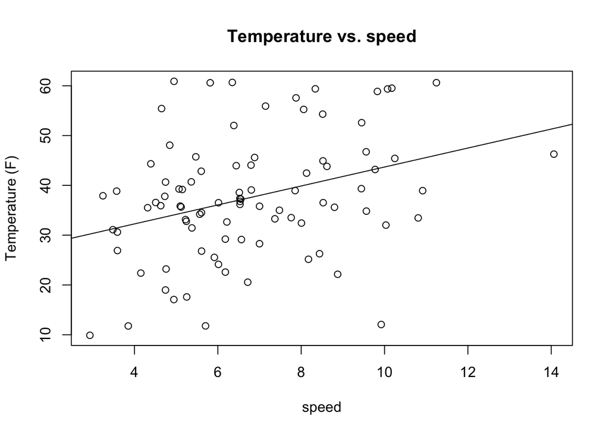

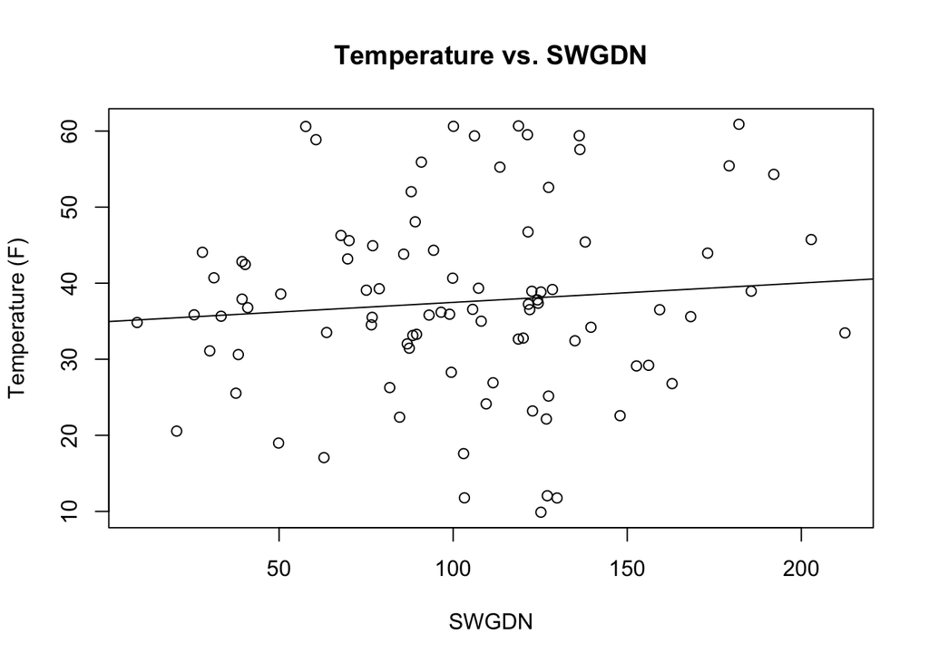

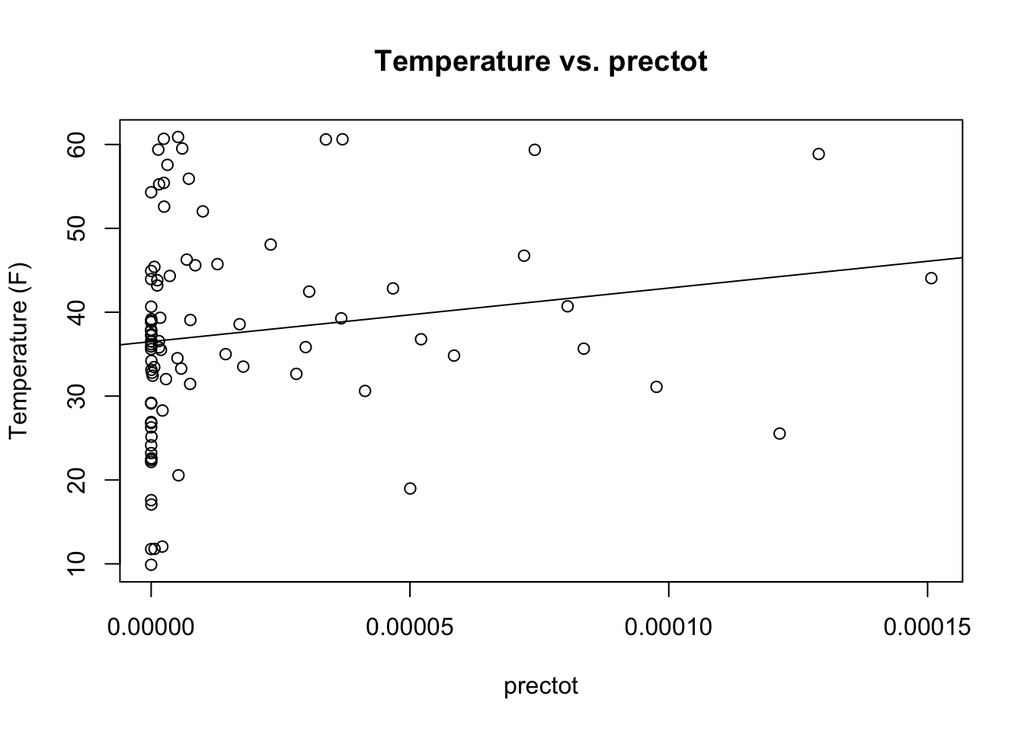

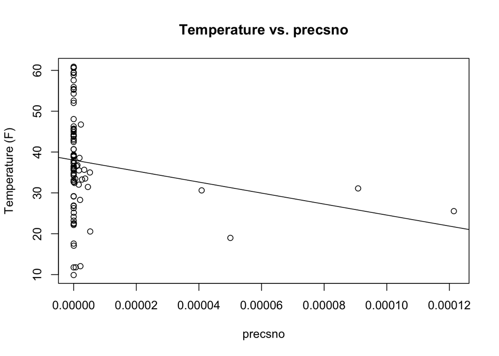

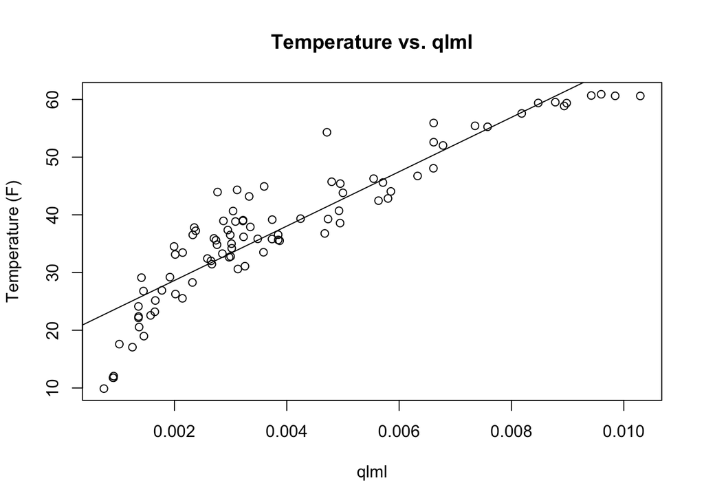

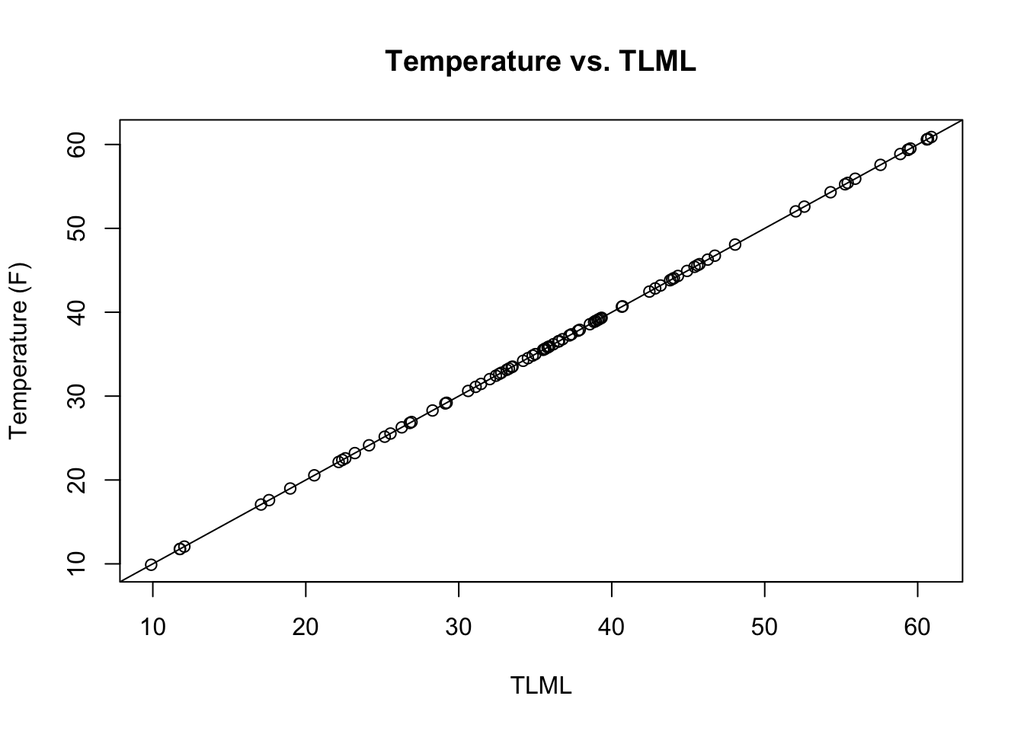

```r
y = belleville_data$TLML
for (col in names(belleville_data)) {
  column = belleville_data[[col]]
  model = lm(y ~ column)
  plot(column, y, xlab = col, ylab = "Temperature (F)", main = paste("Temperature vs.", col))
  abline(model)
}
```

We can also use a correlation matrix to check for any issue regarding colinearity of relevance of the feature variables to the response

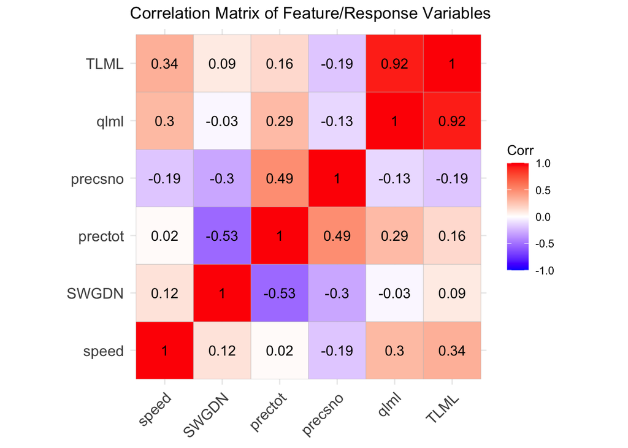

```r
cor_matrix = cor(belleville_data)
library(ggcorrplot)
library(ggplot2)

# Plot the correlation matrix
ggcorrplot(cor_matrix, lab = TRUE) +
  ggtitle("Correlation Matrix of Feature/Response Variables")
```

Let’s discuss these features one-by-one.

Firstly, speed, a measure of wind speed, seems to correlate with higher temperatures. I thought initially that higher winds might correlate with lower temperatures since high wind tends to cool things down, but I think the temperature might be soley measured as the static air temperature, and that any wind chill effects are not represented in the final measure After doing some reading, I learned that high winds can be produced by large temperature differentials. In the winter, there is not much difference between the frigid temperatures of the day and night. However, during the fall and spring here, temperatures can shift dramatically between high and low, which could cause greater wind speeds (which is potentially why tornadoes and storms seem to happen the most in the spring). Because temperature can affect wind, we should keep wind in the final model.

SWGDN is a measure of surface incoming shortwave flux. From what I understand though the internet, this is essentially a proxy for sunlight. Intuitively, this should correlate positively with heat, because the sun generates heat, and cloud cover cools things down. You can also think about the fact that during the summer, days are longer, so a higher SWGDN is at play (although I’m not sure if these tempurautres were measured at one specific point in the day, or throughout the day). Despite this intuition, we see very little relationship between SWGDN and Temperature in the graph. I think St. Louis and the Midwest at large are unique in that cloud cover doesn’t seem to very much with temperature, which is unlike places like, for instance, my hometown of Seattle, in which clouds are seemingly strongly correlated with lower temperatures. I’ve experienced many days in St. Louis in which the sky was totally clear at ~10 degrees, and many days where things were unbearably hot with heavy cloud cover. Because there is no clear relationship between temperature and SWGDN in the training data, as well as because I don’t have knowledge of exactly how this feature was collected, I will leave it out of the model.

Percsno measures snowfall. Since snow only happens with freezing temperatures, its presence is obviously predictive of temperature. I’ll keep it in the model.

QLML measures specific humidity (ratio of water vapor mass to total moist air parcel mass). There is a strong relationship between this and temperature in the training data (0.92 correlation is extremely high), and as anyone who has lived in St. Louis can tell you, it gets very humid during the hot months. I’ll use it in the model.

So the final features I will use in the model are qlml, speed, and percsno.

I’ll will not standardize the features because I want to keep the coefficients of the model interpretable. In other words, I want the coefficients of the model to be in the units of the feature, so I can see for example what one additional m/s increase in wind speed corresponds to *blank* increase in degrees Fahrenheit. Let’s build the model:

```r
model = lm(TLML ~ qlml + precsno +speed, data = belleville_data)
summary(model)
```

```
##
## Call:
## lm(formula = TLML ~ qlml + precsno + speed, data = belleville_data)
##
## Residuals:
##      Min       1Q   Median       3Q      Max
## -13.0221  -2.8128  -0.0922   2.6668  12.2193
##
## Coefficients:
##               Estimate Std. Error t value Pr(>|t|)
## (Intercept)  1.759e+01  1.792e+00   9.817 1.07e-15 ***
## qlml         4.579e+03  2.273e+02  20.145  < 2e-16 ***
## precsno     -4.616e+04  3.089e+04  -1.494    0.139
## speed        3.409e-01  2.527e-01   1.349    0.181
## ---
## Signif. codes:  0 '***' 0.001 '**' 0.01 '*' 0.05 '.' 0.1 ' ' 1
##
## Residual standard error: 4.878 on 86 degrees of freedom
## Multiple R-squared:  0.8477, Adjusted R-squared:  0.8424
## F-statistic: 159.6 on 3 and 86 DF,  p-value: < 2.2e-16
```

This model shows that while qlml is very significant, speed and precsno are not so much significant. This makes some sense, as there is some degree of colinearity between the variables (see that qlml and speed have a correlation of 0.3 in the correlation matrix). It appears that humidity and wind speed are somewhat related which makes physical sense, as high winds tend to happen during stormy, humid periods. Therefore, in the interest of model simplicity, I’m going to make the call to remove wind speed from the model. I’ll leave precsno in because it seems to have low correlation with humidity and the intuitive connection between snow and temperature is still obvious. However, the precsno feature contains two important pieces of information, both the presence of snow, and the amount of precipitation. Since the precipitation is related to humidity, I am going to ignore the magnitude of snowfall and instead focus on its presence, because that is directly related to the temperature. I’ll do this by encoding the variable; *1* signifies snowfall, *0* signifies *no snowfall.* The new feature I will name precsno_mod.

```r
belleville_data$precsno_mod[belleville_data$precsno > 0] = 1
belleville_data$precsno_mod[is.na(belleville_data$precsno_mod)] <- 0
print(belleville_data$precsno_mod)
```

```
##  [1] 1 0 0 1 1 1 1 1 1 1 1 1 1 1 1 1 1 1 1 1 1 1 1 0 1 0 0 1 0 0 0 1 0 0 1 1 1 1
## [39] 1 1 0 1 1 1 1 1 1 0 1 0 0 0 0 0 0 0 1 1 1 1 1 0 0 1 1 1 1 0 0 1 1 1 0 0 1 0
## [77] 1 1 0 0 0 0 0 0 0 0 1 1 0 0
```

```r
model = lm(TLML ~ qlml + precsno_mod, data = belleville_data)
summary(model)
```

```
##
## Call:
## lm(formula = TLML ~ qlml + precsno_mod, data = belleville_data)
##
## Residuals:
##      Min       1Q   Median       3Q      Max
## -13.0423  -2.3720   0.0859   2.7875  12.8358
##
## Coefficients:
##             Estimate Std. Error t value Pr(>|t|)
## (Intercept)   24.622      1.862  13.221  < 2e-16 ***
## qlml        4044.112    286.844  14.099  < 2e-16 ***
## precsno_mod   -4.701      1.391  -3.379  0.00109 **
## ---
## Signif. codes:  0 '***' 0.001 '**' 0.01 '*' 0.05 '.' 0.1 ' ' 1
##
## Residual standard error: 4.686 on 87 degrees of freedom
## Multiple R-squared:  0.8579, Adjusted R-squared:  0.8546
## F-statistic: 262.6 on 2 and 87 DF,  p-value: < 2.2e-16
```

I’m more satisfied with this model because it is simpler and has a similar (but slightly better) R^2 than the previous model. The increased accuracy and lower dimensionality (we dropped a feature) means this model will probably generalize better. Also, now all the features and the inercept have high significance codes! We can see that, as expected, the humidity feature has a positive correlation with temperature, and the binary snow feature has a negative relationship with temperature (presence of snow decreases the response). The qlml feature might seem hugely important based on this coefficient, but its large coefficient is mostly a result of the units qlml is in, which is very small (the feature ranges between 0.0007449141 and 0.0102934623). However, as we can see by the significance code, qlml is still the most important feature in predicting tempurautre.

# Task 2: Model Validation and Prediction

We can use the data_prediction dataset to now test our model. Mean squared error is generally considered to be a good error measure for linear models, so I’ll employ it here to test the viability of our model.

```r
belleville_test_data <- data.frame(
  qlml = data_prediction$QLML[lon_index,lat_index,],
  precsno = data_prediction$precsno[lon_index,lat_index,],
  TLML = data_prediction$TLML[lon_index,lat_index,]
)

belleville_test_data$precsno_mod[belleville_test_data$precsno > 0] = 1
belleville_test_data$precsno_mod[is.na(belleville_test_data$precsno_mod)] <- 0

predictions = predict(model, newdata = belleville_test_data)

mse = mean((predictions - belleville_test_data$TLML)^2)
mse
```

```
## [1] 46.42038
```

The mean squared error of our predictor is 46.4203813. This is pretty low relative to the units of the response and likely indicates that we have a good linear model. We can graph the predicted temperatures with the actual temperatures in data_prediction:

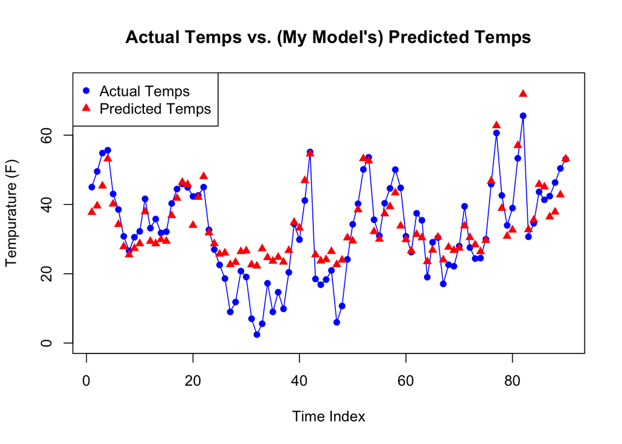

```r
plot(belleville_test_data$TLML, type = "p",col = "blue", pch = 16, xlab = "Time Index", ylab = "Tempurature (F)", main = "Actual Temps vs. (My Model's) Predicted Temps", ylim = c(0, 75))
lines(belleville_test_data$TLML, col = "blue")
points(predictions, col = "red", type = "p", pch = 17)
legend("topleft", legend = c("Actual Temps", "Predicted Temps"), col = c("blue", "red"), pch = c(16, 17))
```

Based on the chart above, it appears as if my model can predict tempuratures at Belleville with pretty good accuracy. However, my model seems to be conservative when it comes to outputting low tempuratures, as it doesn’t really seem to predict values below 20F (this makes sense based on the coefficients. The intercept is ~24.5, while the snow coefficient is -4.7. Meanwhile, qlml can’t be negative, so the lowest tempurautre the model can output is a little less than 20F).

Temperature Map

We are going to make a temperature map now that displays the actual temperatures for every coordinate combination in the grid. I’ll set the time index to an arbitrary value, let’s say time_index = 45.

```r
coords = expand.grid(data_training$lon, data_training$lat)

coords <- data.frame(
  lon = coords$Var1,
  lat = coords$Var2,
  prediction = rep(0, length(coords))
)

temp_predictions = c()
latts = c()
lonns = c()
i = 0
for (lat_index in (1:length(data_training$lat))){
  for (lon_index in (1:length(data_training$lon))){
    i = i+1
    #temp_prediction <- data.frame(
      #qlml = data_prediction$QLML[lon_index,lat_index,],
      #precsno = data_prediction$precsno[lon_index,lat_index,],
      #TLML = data_prediction$TLML[lon_index,lat_index,]
    #)
    #temp_prediction_data$precsno_mod[temp_prediction_data$precsno > 0] = 1
    #temp_prediction_data$precsno_mod[is.na(temp_prediction_data$precsno_mod)] <- 0

    #prediction_thing = predict(model, newdata = temp_prediction_data)
    predictoin_thing = data_prediction$TLML[lon_index,lat_index,45]

    coords$prediction[i] = predictoin_thing
    #temp_predictions  = c(temp_predictions, mean(prediction_thing))
    latts = c(latts, lat_index)
    lonns = c(lonns, lon_index)
  }
}

coords$latts = latts
coords$lonns = lonns
```

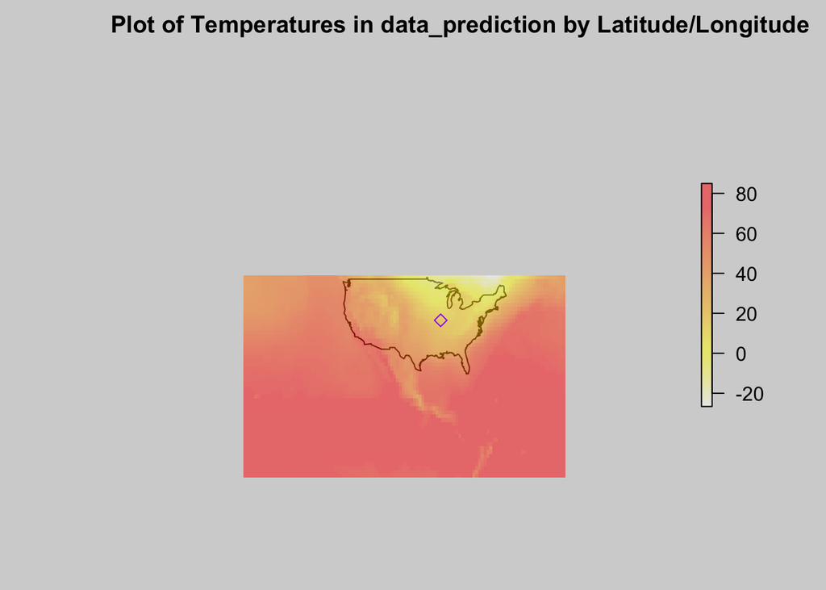

```r
library(ggplot2)
library(maps)
library(sp)
library(raster)
library(maps)

world_map <- map_data("world")

# Plot the coordinates on a world map
# Create a basic world map
par(mar = c(0, 0, 2, 0))
map("usa", fill = TRUE, col = "lightgray", bg = "lightgrey", xlim = c(-200, 0), ylim = c(-10,100))

# Add points for the coordinates
#points(coords$lon, coords$lat, col = "red", pch = 19, cex = 1.5)
#coordinates(coords) <- ~lon+lat

# Create a spatial data frame with predictions
sp_points <- SpatialPointsDataFrame(coords[,1:2], data.frame(prediction = coords$prediction))

# Convert points to a raster
raster_res <- 1  # Resolution of the raster (e.g., 1 degree grid)
r <- raster(extent(-180, 180, -90, 90), res = raster_res)
r <- rasterize(sp_points, r, field = "prediction", fun = mean)

# Plot the raster as a heatmap (add it to the world map)
plot(r, col = rev(heat.colors(100)), alpha = 0.5, add = TRUE, box = FALSE, axes = FALSE, border= NA)

points(-90.20, 38.63, col = "purple", pch = 5)

title(main = "Plot of Temperatures in data_prediction by Latitude/Longitude")
```

St. Louis is highlighted in purple in the graph above. Let’s make another temperature heat map, but this time replace the actual value for St. Louis with the predicted value for St. Louis.

```r
# Changing out the actual value with the predicted value.
prediction_single = predict(model, newdata = belleville_test_data[45,])
coords[(coords$lat == 38.5)  & (coords$lon == -90), "prediction"] = prediction_single
```

Now that we’ve replaced the true value with the prediction, we can print an updated map. Once again, St. Louis is highlighted in the purple square:

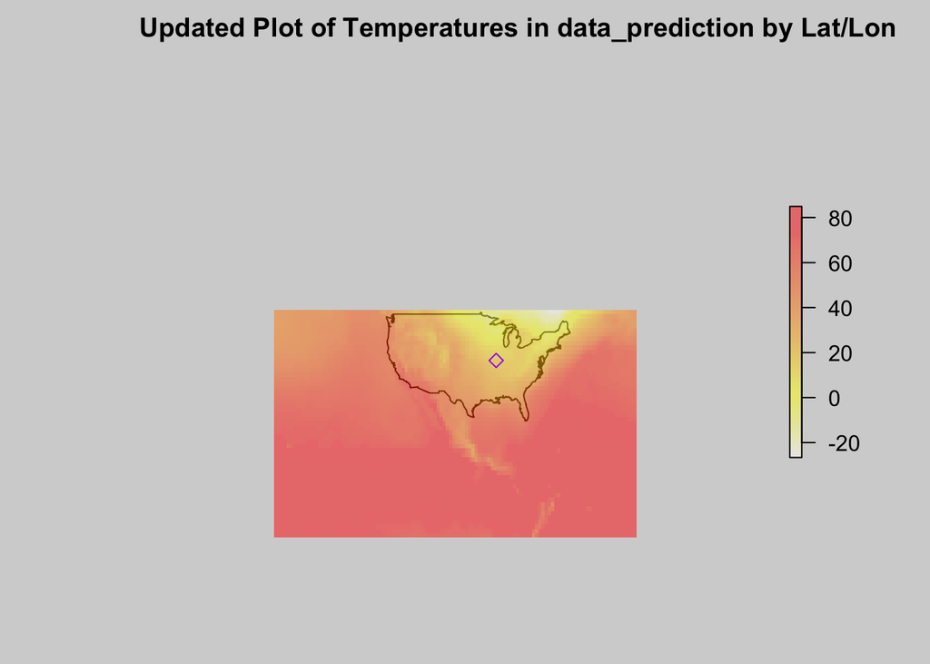

```r
world_map <- map_data("world")

# Plot the coordinates on a world map
# Create a basic world map
par(mar = c(0, 0, 2, 0))
map("usa", fill = TRUE, col = "lightgray", bg = "lightgrey", xlim = c(-200, 0), ylim = c(-10,100))

# Add points for the coordinates
#points(coords$lon, coords$lat, col = "red", pch = 19, cex = 1.5)
#coordinates(coords) <- ~lon+lat

# Create a spatial data frame with predictions
sp_points <- SpatialPointsDataFrame(coords[,1:2], data.frame(prediction = coords$prediction))

# Convert points to a raster
raster_res <- 1  # Resolution of the raster (e.g., 1 degree grid)
r <- raster(extent(-180, 180, -90, 90), res = raster_res)
r <- rasterize(sp_points, r, field = "prediction", fun = mean)

# Plot the raster as a heatmap (add it to the world map)
plot(r, col = rev(heat.colors(100)), alpha = 0.5, add = TRUE, box = FALSE, axes = FALSE, border= NA)

points(-90.20, 38.63, col = "purple", pch = 5)

title(main = "Updated Plot of Temperatures in data_prediction by Lat/Lon")
```

# Task 3: Bootstrap Analysis

We can use the bootstrap to estimate certain aspects of certain parameters. In this case, it would be nice to estimate certain aspects of the parameters for the linear model we have created. More specifically, it would be nice to get information about the coefficients and bias of the multivariate linear model I’ve created.

One of the simplest implementations of the bootstrap is bootstrapping for the standard error of the coefficients. We can do that be resampling on the training data a bunch and then creating a bunch of different linear models. We can use those resampled models and extract their coefficients, using the formula from class to generate estimates for the bias.

```r
# B = 50 should be enough for standard error
B = 50
n = length(belleville_data$speed)

set.seed(475)

theta_bootstrap =  vector("numeric", B)

biases = c()
B1s = c()
B2s = c()

for (b in 1:B){
  indices = sample(1:n, size = n, replace = TRUE)
  temp_data = belleville_data[indices,]
  temp_model = lm(TLML ~ qlml + precsno_mod, data = temp_data)
  coefs = temp_model$coefficients
  biases = c(biases, coefs[1])
  B1s = c(B1s, coefs[2])
  B2s = c(B2s, coefs[3])
}

# We can now calculate the standard error of all coefficients

mean_bias = mean(biases)
se_bias = sqrt(sum((biases - mean_bias)^2) /(B-1))
print("intercept se:")
```

```
## [1] "intercept se:"
```

```r
print(se_bias)
```

```
## [1] 1.835482
```

```r
mean_B1s = mean(B1s)
se_B1s = sqrt(sum((B1s - mean_B1s)^2) /(B-1))
print("qlml coefficient se:")
```

```
## [1] "qlml coefficient se:"
```

```r
print(se_B1s)
```

```
## [1] 266.8153
```

```r
mean_B2s = mean(B2s)
se_B2s = sqrt(sum((B2s - mean_B2s)^2) /(B-1))
print("precsno_mod coefficient se:")
```

```
## [1] "precsno_mod coefficient se:"
```

```r
print(se_B2s)
```

```
## [1] 1.185595
```

The bootstrap standard error for the intercept is 1.8354819, the bootstrap standard error for the humidity coefficient is 266.8152959, and the bootstrap standard error the modified snow variable is 1.1855948. This is a good way of quantifying uncertainty in our model. At face value, it seems like the qlml feature has extremely high standard error, but that’s mostly because the units for the feature are so small. All of the coefficients have reasonably low variance when you account for their units, although proportionally to the size of the coefficient, the precsno_mod standard error is the most significant.

We can also easily estimate the bias of the coefficients using the bootstraps we calculated earlier using the bias bootstrap method. This is a very simple method that involves subtracitng the mean of the bootstrap estimates with the original values we got for the coefficients of the model. You can see the process outlined below.

```r
og_bias = model$coefficients[1]
og_B1 = model$coefficients[2]
og_B2 = model$coefficients[3]

mean_bias = mean(biases)
bias_bias = mean_bias - og_bias

mean_B1 = mean(B1s)
B1_bias = mean_B1 - og_B1

mean_B2 = mean(B2s)
B2_bias = mean_B2 - og_B2

print("Bias estimates:")
```

```
## [1] "Bias estimates:"
```

```r
print(bias_bias)
```

```
## (Intercept)
##  -0.1277783
```

```r
print(B1_bias)
```

```
##     qlml
## 4.141797
```

```r
print(B2_bias)
```

```
## precsno_mod
##   0.2246104
```

Above are the bootstrap estimates for the bias for the different parameters of the model. None of these are particularly worrying to me, and may be the result of random noise. Once again, the bias of the qlml seems high, but that’s mostly because its units are so small in comparison to tlml’s, so the coefficient is naturally big. Even though these values are pretty small, it might be worth trying to create a bias-corrected model in the future.

Let’s also a make a confidence interval for the parameters to figure out their approximate true range. To keep things simple, I’ll use a basic bootstrap confidence interval, in which we construct a confidence interval using the $\alpha/2$ percentile bootstrap estimates. The formula is as follows:

$$(2\hat{\theta} -
\hat{\theta}^*_{1-\alpha/2},\
2\hat{\theta}-\hat{\theta}^*_{\alpha/2})$$
We can again use the bootstrap parameters we calculated earlier for this. Let’s set a reasonable value of $\alpha = 0.05$. Since we don’t have a lot of bootstrap replicates, we have to generate more for this part of the process, on the order to 1000.

```r
# We need a much higher B because confidence intervals require that
B = 1000
n = length(belleville_data$speed)

theta_bootstrap =  vector("numeric", B)

biases = c()
B1s = c()
B2s = c()

for (b in 1:B){
  indices = sample(1:n, size = n, replace = TRUE)
  temp_data = belleville_data[indices,]
  temp_model = lm(TLML ~ qlml + precsno_mod, data = temp_data)
  coefs = temp_model$coefficients
  biases = c(biases, coefs[1])
  B1s = c(B1s, coefs[2])
  B2s = c(B2s, coefs[3])
}
```

```r
range = c(0.975, 0.025)
bias_ranges = quantile(biases, probs = range)

bias_interval = 2*og_bias - bias_ranges

bias_interval <- c("2.5%" = as.numeric(bias_interval[1]), "97.5%" = as.numeric(bias_interval[2]))
print("Intercept CI:")
```

```
## [1] "Intercept CI:"
```

```r
print(bias_interval)
```

```
##     2.5%    97.5%
## 21.58913 28.55073
```

```r
B1_ranges = quantile(B1s, probs = range)

B1_interval = 2*og_B1 - B1_ranges

B1_interval <- c("2.5%" = as.numeric(B1_interval[1]), "97.5%" = as.numeric(B1_interval[2]))
print("qlml CI:")
```

```
## [1] "qlml CI:"
```

```r
print(B1_interval)
```

```
##     2.5%    97.5%
## 3482.959 4478.358
```

```r
B2_ranges = quantile(B2s, probs = range)

B2_interval = 2*og_B2 - B2_ranges

B2_interval <- c("2.5%" = as.numeric(B2_interval[1]), "97.5%" = as.numeric(B2_interval[2]))
print("precosno_mod CI:")
```

```
## [1] "precosno_mod CI:"
```

```r
print(B2_interval)
```

```
##      2.5%     97.5%
## -7.270997 -2.599733
```

To summarize, we can say with 95% confidence that the intercept of the model is in the range (21.5891342, 28.5507307). With 95% confidence, the qlml coefficient is between (3482.9588285, 4478.3581599), and with 95% confidence, the precsno_mod coefficient is between (-7.2709971, -2.5997333). This are pretty decent ranges, and we can now confirm that the coefficients, with 95% confidence, are at least in the same ballpark as the ones we calculated.

As a sanity check, we can use a built-in R function to calculate some confidence intervals for the parameters:

```r
confint(model, method = "boot")
```

```
##                   2.5 %      97.5 %
## (Intercept)   20.920732   28.323856
## qlml        3473.978008 4614.246515
## precsno_mod   -7.466297   -1.935929
```

# Task 4: Gibbs Sampler for MCMC Analysis

I’m going to use Gibbs Sampler to model the dependency of the intercept and coefficient and generate samples. I don’t think that Gibbs sampler works very well with binary variables, so I’m going to axe the snow feature and just focus on modeling the humidity with respect to the temperature.

My process for this going to be similar to the one outlined in Jonny Law’s website at “https://jonnylaw.rocks/posts/2019-06-14-bayesian-linear-regression/”. In this model, we have to estimate the precision (inverse of the variance) and as well as the intercept $\alpha$ and coefficient $\beta$. They are distributed as follows:

$$p(\tau) = Gamma(\alpha_{\sigma},
\beta_{\sigma}),$$

$$p(\alpha) = N(\mu_{\alpha},
\sigma^2_{\alpha}),$$
$$p(\beta) =
N(\mu_{\beta}, \sigma^2_{\beta}).$$

Just like in class, we will cycle between these values, plugging one case into the other.

Here are these probability generating function written out in code (again, courtesy of Jonny Law and his website).

```r
tau_sampler = function(alpha_tau, beta_tau, alpha, beta, x, y){
  shape1 = alpha_tau + length(y)/2
  rate1 = beta_tau + 0.5*sum( (y - alpha - x*beta)^2 )

  output = rgamma(1, shape = shape1, rate = rate1)
  return(output)
}

alpha_sampler = function(tau_alpha, tau, beta, x, y){
  precision = tau_alpha + length(y)*tau
  mean = (tau_alpha + tau*sum(y- x * beta)) / precision
  return(rnorm(1, mean, sd = 1 /sqrt(precision)))
}

beta_sampler = function(tau_beta, tau, alpha, x, y){
  precision = tau_beta + tau*sum(x^2)
  mean = (tau_beta + tau*sum((y-alpha)*x)) / precision
  return(rnorm(1, mean, sd = 1 /sqrt(precision)))
}
```

There is a also an implementation of the algorithm that I’ve adapted:

```r
gibbs_sampler = function(x, y, tau0, alpha0, beta0, n_iters, alpha_tau, beta_tau, mu_alpha, tau_alpha, mu_beta, tau_beta, burn_in){

  taus = numeric(n_iters)
  alphas = numeric(n_iters)
  betas = numeric(n_iters)

  taus[1] = tau0
  alphas[1] = alpha0
  betas[1] = beta0

  # some normalization
  x = x - mean(x)
  for(i in 2:n_iters){
    taus[i] = tau_sampler(alpha_tau, beta_tau, alphas[i-1], betas[i-1], x, y)
    alphas[i] = alpha_sampler(tau_alpha, taus[i], betas[i-1], x, y)
    betas[i] = beta_sampler(tau_beta, taus[i], alphas[i], x, y)
  }
  # Remove burn-in samples
  return(data.frame(tau = taus[(burn_in + 1):n_iters], alpha = alphas[(burn_in + 1):n_iters], beta = betas[(burn_in + 1):n_iters]))
}
```

Now we can use these functions to implement the code. I based the parameters for alpha (the intercept) and beta (the humidity parameter) off their respective standard errors I calculated during the bootstrapping process so that I could get good priors. Because the model takes precision as an input, which is the inverse of the variance, I took the inverse of the squared bootstrap standard errors for both the intercept and the humidity coefficient to have decent priors. Also, I set the A parameter very high for the Tau’s assumed gamma distribution, because I heard this was a measure of confidence in the priors. I also had 10000 iterations and 2000 burn-ins, so hopefully the model will converge.

```r
n_iters = 10000
burn_in = 2000
x = belleville_data$qlml
y = belleville_data$TLML

tau0 = 0.001 # almost no effect
alpha0 = 6 # almost no effect
beta0 = 5000 # almost no effect

alpha_tau = 10000 # very large effect (especially on beta) (Think it represents confidence in data?)
beta_tau = 10 # Large effect on beta

mu_alpha = 3 # no effect
tau_alpha = 0.2968245 # pretty decent effect

mu_beta = 4 # no effect
tau_beta = 1.404684e-05 # Large effect


thing = gibbs_sampler(x, y, tau0, alpha0, beta0, n_iters, alpha_tau, beta_tau, mu_alpha, tau_alpha, mu_beta, tau_beta, burn_in)

beta_gibbs = mean(thing$beta)
intercept_gibbs = mean(thing$alpha)

print(beta_gibbs)
```

```
## [1] 4697.829
```

```r
print(intercept_gibbs)
```

```
## [1] 37.5155
```

The outputted values for the linear regression model were 4697.8289979 for the coefficient and 37.5154989 for the intercept. Let’s make sure our model converged:

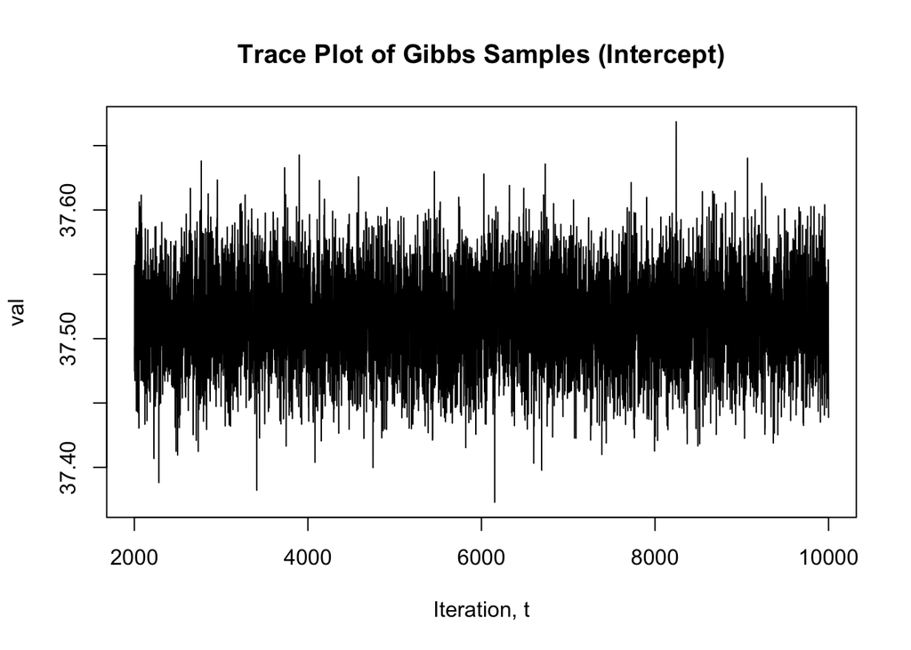

```r
plot(x = (2001:10000), y = thing$alpha, type = "l", xlab = "Iteration, t", ylab = "val", main = "Trace Plot of Gibbs Samples (Intercept)")
```

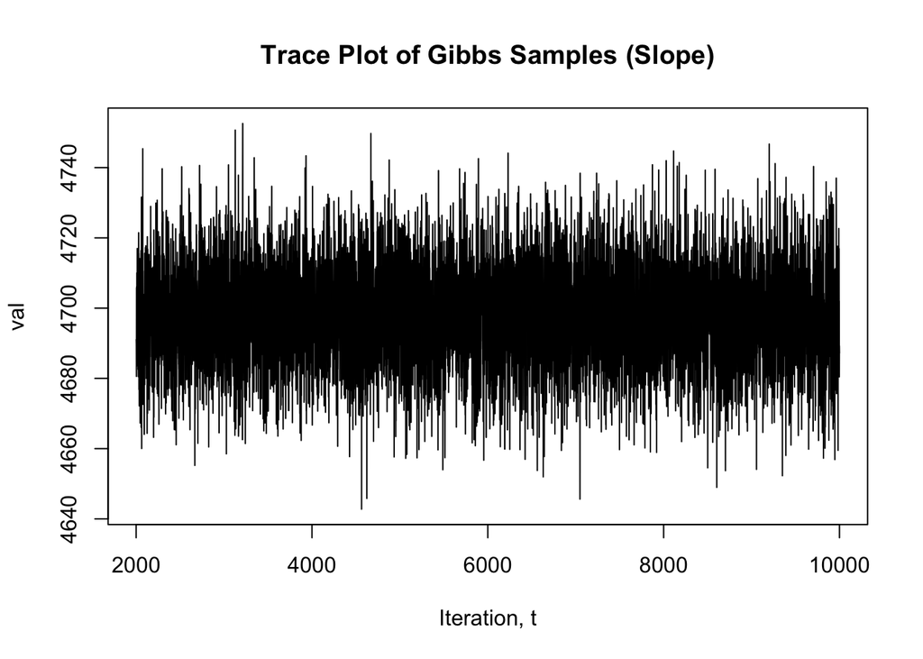

```r
plot(x = (2001:10000), y = thing$beta, type = "l", xlab = "Iteration, t", ylab = "val", main = "Trace Plot of Gibbs Samples (Slope)")
```

In both of these graphs, it appears as if our sampler has more or less converged, because there are no obvious trends and the generated data looks pretty random. So our intercept and slope are probably decent.

We can use these to make predictions and get a MSE:

```r
belleville_gibbs_model = function(x){
  return(beta_gibbs*x + intercept_gibbs)
}


gibbs_preds = belleville_gibbs_model(belleville_test_data$qlml)
margins = gibbs_preds - belleville_test_data$TLML

mse_gibbs = mean(margins^2)

mse_gibbs
```

```
## [1] 420.8649
```